# Tanager Evolution Project Notes

```r
# Save the table as a CSV
write.csv(spline_table, "spline_summary_table.csv", row.names = FALSE)

# Fixing the PDF export by increasing the margins and adjusting the layout
pdf("spline_summary_table.pdf", width = 11, height = 8.5)
gridExtra::grid.table(spline_table, rows = NULL)
dev.off()
```

### Step 7: Model scores table for reflectance and log reflectance splines

Here, we want to create a separate data frame in order to easily compare the model scores for the spline fits to each set of data (reflectance versus log-transformed reflectance values). This data frame will contain the AIC, BIC, and logLik scores that we obtained from our gls function and then we identify which model has the “better” score, and therefore which dataset we should use for our parameter estimation and ancestral state reconstruction.

```r
# Creates a separate data frame only containing the species names and the model scores produced from our gls
spline_model_scores <- spline_table[,c(1,4:9)]

# Adds a column to the end of the data frame capturing the minimum AIC score between the two fits (lowest AIC score is the model you should select)
spline_model_scores <- spline_model_scores %>%
  group_by(Species) %>%
  mutate(AIC_Preferred_Model_Score = min(c(Reflectance_AIC, Log_Reflectance_AIC)))

# Here we create a for loop system to identify and name which dataset used is preferred without having to manually check for each species.

# Placeholder vector to store which dataset is preferred to then be bound to the end of the model scoring data frame
preferred_model_name <- rep(NA, length(spline_model_scores$Species))

# for loop to determine which value (for each species) from our newly generated column matches to which dataset and store the output into the placeholder vector
for (i in 1:length(spline_model_scores$Species)){
  if (spline_model_scores[i,8] == spline_model_scores[i,2]){
    preferred_model_name[i] <- "Reflectance"
  }
  else if (spline_model_scores[i,8] == spline_model_scores[i,3]){
    preferred_model_name[i] <- "Log Reflectance"
  }
  else if (spline_model_scores[i,8] == spline_model_scores[i,2] & spline_model_scores[i,3] == spline_model_scores[i,8]){
    preferred_model_name[i] <- "Either"
  }
    }

# Attaches the placeholder vector to the model scores data frame
spline_model_scores <- cbind(spline_model_scores, preferred_model_name)
# Takes the column names of the data frame and stores them in a vector
column_names <- colnames(spline_model_scores)

# Adds a new value to name our newly attached column
column_names[9] <- "AIC_Preferred_Model_Name"

# Applies our column names vector as the names for our data frame
colnames(spline_model_scores) <- column_names



# We recreate an identical process for BIC scores

spline_model_scores <- spline_model_scores %>%
  group_by(Species) %>%
  mutate(BIC_Preferred_Model_Score = min(c(Reflectance_BIC, Log_Reflectance_BIC)))

preferred_model_name <- rep(NA, length(spline_model_scores$Species))
for (i in 1:length(spline_model_scores$Species)){
  if (spline_model_scores[i,10] == spline_model_scores[i,4]){
    preferred_model_name[i] <- "Reflectance"
  }
  else if (spline_model_scores[i,10] == spline_model_scores[i,5]){
    preferred_model_name[i] <- "Log Reflectance"
  }
  else if (spline_model_scores[i,10] == spline_model_scores[i,4] & spline_model_scores[i,5] == spline_model_scores[i,10]){
    preferred_model_name[i] <- "Either"
  }
    }

spline_model_scores <- cbind(spline_model_scores, preferred_model_name)
column_names <- colnames(spline_model_scores)
column_names[11] <- "BIC_Preferred_Model_Name"
colnames(spline_model_scores) <- column_names



# We create an almost identical process for logLik scores. The only change is that instead of looking for the minimum logLik score, we are looking for the maximum logLik score.

spline_model_scores <- spline_model_scores %>%
  group_by(Species) %>%
  mutate(logLik_Preferred_Model_Score = max(c(Reflectance_logLik, Log_Reflectance_logLik)))

preferred_model_name <- rep(NA, length(spline_model_scores$Species))
for (i in 1:length(spline_model_scores$Species)){
  if (spline_model_scores[i,12] == spline_model_scores[i,6]){
    preferred_model_name[i] <- "Reflectance"
  }
  else if (spline_model_scores[i,12] == spline_model_scores[i,7]){
    preferred_model_name[i] <- "Log Reflectance"
  }
  else if (spline_model_scores[i,12] == spline_model_scores[i,6] & spline_model_scores[i,7] == spline_model_scores[i,12]){
    preferred_model_name[i] <- "Either"
  }
    }

spline_model_scores <- cbind(spline_model_scores, preferred_model_name)
column_names <- colnames(spline_model_scores)
column_names[13] <- "logLik_Preferred_Model_Name"
colnames(spline_model_scores) <- column_names

spline_model_scores$logLik_Preferred_Model_Name[spline_model_scores$logLik_Preferred_Model_Name == 0] <- "Reflectance"
spline_model_scores$logLik_Preferred_Model_Name[spline_model_scores$logLik_Preferred_Model_Name == 1] <- "Log Reflectance"
spline_model_scores$logLik_Preferred_Model_Name[spline_model_scores$logLik_Preferred_Model_Name == 2] <- "Either"

# Reorders the data frame to put all of the model scores together
spline_model_scores <- spline_model_scores[,c(1,2,3,8,9,4,5,10,11,6,7,12,13)]

# Verifies if the data frame has been completed correctly
head(spline_model_scores)
```

```
## # A tibble: 6 × 13
## # Groups:   Species [6]
##   Species Reflectance_AIC Log_Reflectance_AIC AIC_Preferred_Model_Score
##   <chr>             <dbl>               <dbl>                     <dbl>
## 1 TanCyo           -447.               -1746.                    -1746.
## 2 TanLab             94.0              -1355.                    -1355.
## 3 TanRue           -161.               -1471.                    -1471.
## 4 TanChi           -261.                -999.                     -999.
## 5 TanVel           -667.               -1691.                    -1691.
## 6 TanCal           -210.               -1636.                    -1636.
## # ℹ 9 more variables: AIC_Preferred_Model_Name <chr>, Reflectance_BIC <dbl>,
## #   Log_Reflectance_BIC <dbl>, BIC_Preferred_Model_Score <dbl>,
## #   BIC_Preferred_Model_Name <chr>, Reflectance_logLik <dbl>,
## #   Log_Reflectance_logLik <dbl>, logLik_Preferred_Model_Score <dbl>,
## #   logLik_Preferred_Model_Name <chr>
```

# Step 8: Plotting model scores between datasets

Here, we want to plot the model scores from each of the datasets to each other. If our spline fits are identical, our model scores should fit along the line $y=x$. For an inconclusive determination, we would see an even split around the line if there is not a strong preference present. Otherwise, we should expect to a vast majority of data points lying on one side of the line over the other.

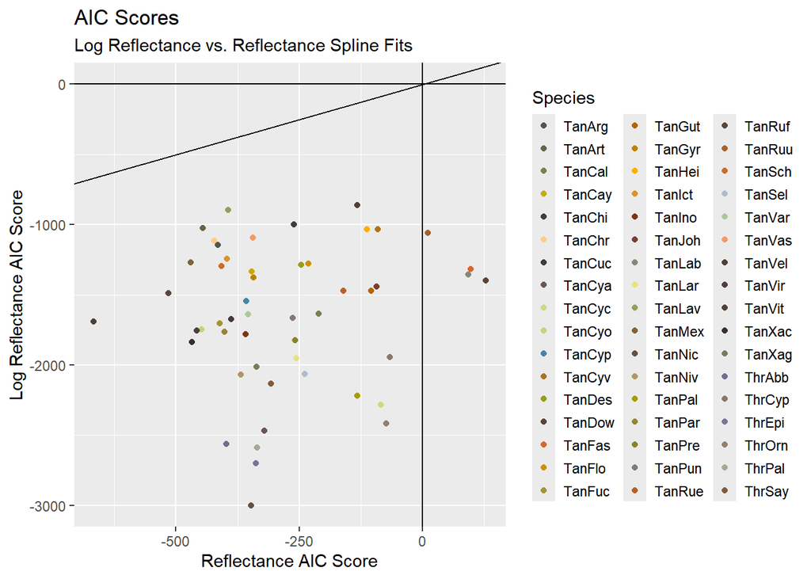

```r
# Create a vector of the color codes for each species to use in ggplot2 scatterplots
tanager_subset_colors <- c(spline_table[, "RGB_Color"])

# Puts the species name for each color as the names for the vector
names(tanager_subset_colors) <- spline_table$Species

# Character vector to be used as the title for our scatterplot legend (there could be other methods of doing this, but this was the one that I could figure out how to use with ggplot2)
title_for_legend <- "Species"


# AIC scores

# Scatterplot showing data spaced around the origin with y=x line present
(ggplot(data = spline_model_scores, aes(x = Reflectance_AIC, y = Log_Reflectance_AIC))
+ geom_point(aes(color = names(tanager_subset_colors)))
+ theme(legend.key.size = unit(0.5, "cm"))
+ geom_hline(yintercept = 0)
+ geom_vline(xintercept = 0)
+ geom_abline(intercept = 0, slope = 1)
+ xlab("Reflectance AIC Score")
+ ylab("Log Reflectance AIC Score")
+ ggtitle("AIC Scores", subtitle = "Log Reflectance vs. Reflectance Spline Fits")
+ scale_color_manual(title_for_legend,values = as.character(tanager_subset_colors))
)
```

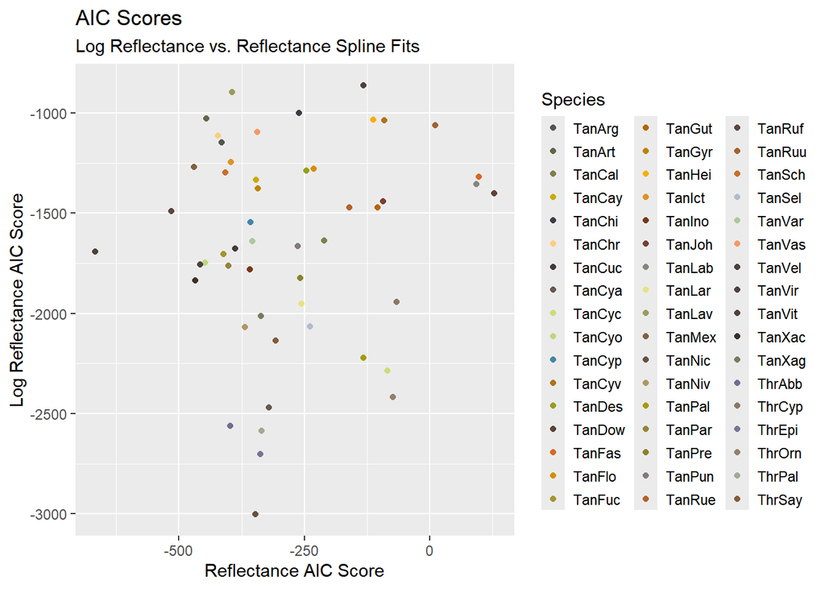

```r
# Scatterplot centered around the data
(ggplot(data = spline_model_scores, aes(x = Reflectance_AIC, y = Log_Reflectance_AIC))
+ geom_point(aes(color = names(tanager_subset_colors)))
+ theme(legend.key.size = unit(0.5, "cm"))
+ xlab("Reflectance AIC Score")
+ ylab("Log Reflectance AIC Score")
+ ggtitle("AIC Scores", subtitle = "Log Reflectance vs. Reflectance Spline Fits")
+ scale_color_manual(title_for_legend,values = as.character(tanager_subset_colors))
)
```

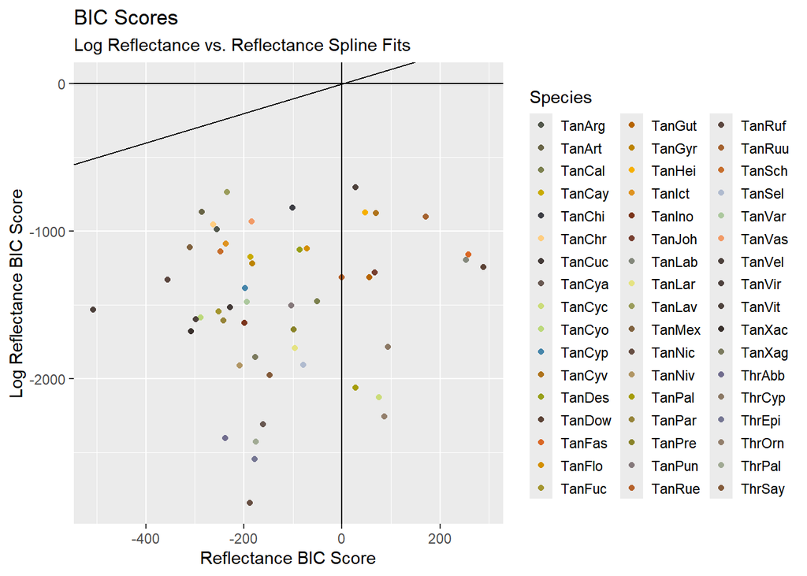

```r
# BIC scores

# Scatterplot showing data spaced around the origin with y=x line present
(ggplot(data = spline_model_scores, aes(x = Reflectance_BIC, y = Log_Reflectance_BIC))
+ geom_point(aes(color = names(tanager_subset_colors)))
+ theme(legend.key.size = unit(0.5, "cm"))
+ geom_hline(yintercept = 0)
+ geom_vline(xintercept = 0)
+ geom_abline(intercept = 0, slope = 1)
+ xlab("Reflectance BIC Score")
+ ylab("Log Reflectance BIC Score")
+ ggtitle("BIC Scores", subtitle = "Log Reflectance vs. Reflectance Spline Fits")
+ scale_color_manual(title_for_legend,values = as.character(tanager_subset_colors))
)
```

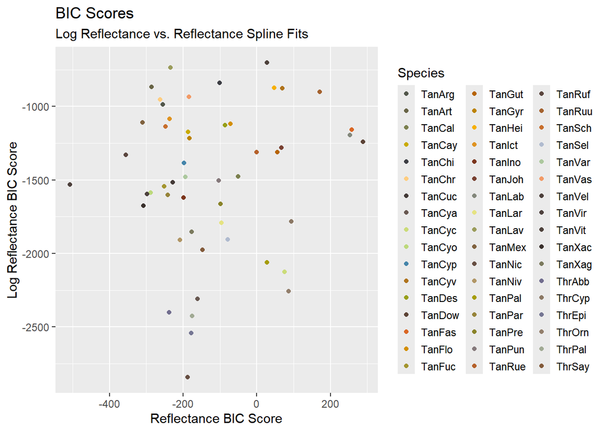

```r
# Scatterplot centered around the data
(ggplot(data = spline_model_scores, aes(x = Reflectance_BIC, y = Log_Reflectance_BIC))
+ geom_point(aes(color = names(tanager_subset_colors)))
+ theme(legend.key.size = unit(0.5, "cm"))
+ xlab("Reflectance BIC Score")
+ ylab("Log Reflectance BIC Score")
+ ggtitle("BIC Scores", subtitle = "Log Reflectance vs. Reflectance Spline Fits")
+ scale_color_manual(title_for_legend,values = as.character(tanager_subset_colors))
)
```

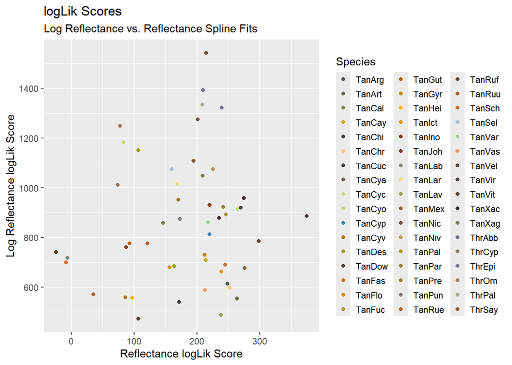

```r
# logLik scores

# Scatterplot showing data spaced around the origin with y=x line present
(ggplot(data = spline_model_scores, aes(x = Reflectance_logLik, y = Log_Reflectance_logLik)) + geom_point(aes(color = names(tanager_subset_colors)))
+ theme(legend.key.size = unit(0.5, "cm"))
+ xlab("Reflectance logLik Score")
+ ylab("Log Reflectance logLik Score")
+ ggtitle("logLik Scores", subtitle = "Log Reflectance vs. Reflectance Spline Fits")
+ scale_color_manual(title_for_legend, values = as.character(tanager_subset_colors))
)
```

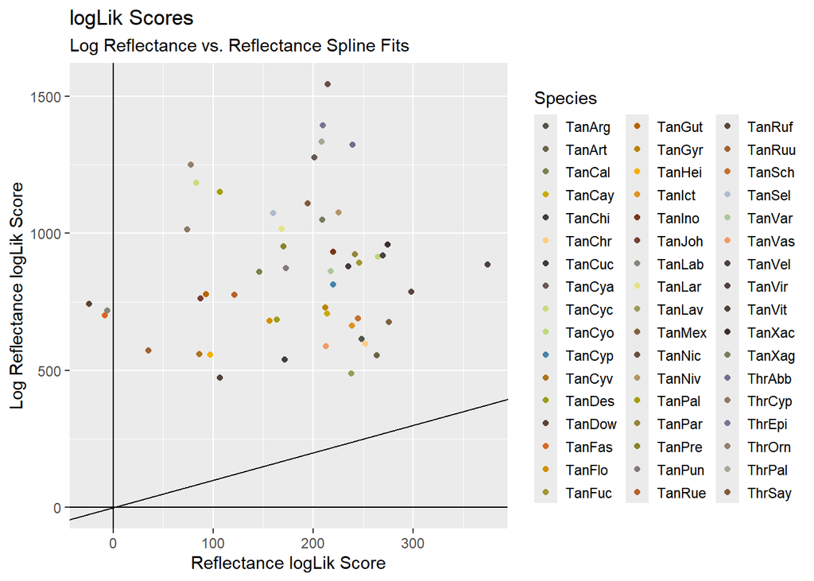

```r
# Scatterplot centered around the data
(ggplot(data = spline_model_scores, aes(x = Reflectance_logLik, y = Log_Reflectance_logLik)) + geom_point(aes(color = names(tanager_subset_colors)))
+ theme(legend.key.size = unit(0.5, "cm"))
+ geom_hline(yintercept = 0)
+ geom_vline(xintercept = 0)
+ geom_abline(slope = 1, intercept = 0)
+ xlab("Reflectance logLik Score")
+ ylab("Log Reflectance logLik Score")
+ ggtitle("logLik Scores", subtitle = "Log Reflectance vs. Reflectance Spline Fits")
+ scale_color_manual(title_for_legend, values = as.character(tanager_subset_colors))
)
```

#Step 9: Summary statistics for 10nm wavelength bins from 300 to 700 nm

```r
# Creates a data frame without a column for the wavelengths
tanData_filtered_wowl <- data.frame(tanData_filtered[-1])
# Transpose the data frame to put the species names as the rows
tanData_filtered_wowl <- t(tanData_filtered_wowl)

# Create a counting vector for our for loop below
wl_bins <- seq(1, 400, 10)

# Creates a wavelength vector to match our counting vector to what our binned wavelengths would be
wavelengths <- 300:700

# 3 blank vectors to add summary statistics to. Each respectively will contain the mean, variance, and standard deviation for each 10nm wavelength bin
wl_mean <- rep(NA, 40)
wl_var <- rep(NA, 40)
wl_sd <- rep(NA, 40)

# One vector to store the raw data and a blank data frame to store all of the reflectance values for each wavelength bin
wl_data <- NULL
wl_dataframe <- NA

# for loop to extract the mean, var, and sd from each wavelength bin by using a sequence of columns and performing a summary function on that group of data. Each value is stored in its respective vector and the data is stored within our data frame. For the final bin of data, which has length 11 rather than 10, we do not attach it to our data frame, and leave it stored in our wl_data vector.
for (i in 1:40){
  # Creates our 10nm bins up until 690 nm
  sequence <- seq(wl_bins[i],(wl_bins[i])+9, 1)

  # Verifies that our vector is working and can match it to our wavelength bins for future clarification
  print(sequence)
  print(wavelengths[sequence])

  # Summary stats are stored in their respective locations
  wl_mean[i] <- mean(tanData_filtered_wowl[,sequence])
  wl_var[i] <- var(tanData_filtered_wowl[,sequence])
  wl_sd[i] <- sd(tanData_filtered_wowl[,sequence])

  # Takes the reflectance values from our data frame and stores them in a vector
  wl_data <- c(tanData_filtered_wowl[,sequence])

  # Takes our vector and stores them within a data frame for future use
  wl_dataframe <- rbind(wl_dataframe, wl_data)

  # Need to add this condition due to unequal wavelength bin sizes
  if (i == 40){
    sequence <- 390:400
    print(sequence)

    wl_mean[i] <- mean(tanData_filtered_wowl[,sequence])
    wl_var[i] <- var(tanData_filtered_wowl[,sequence])
    wl_sd[i] <- sd(tanData_filtered_wowl[,sequence])

    wl_data <- c(tanData_filtered_wowl[,sequence])
  }

  # Verifies that the length of each bin is 10 nm intervals except for our final interval, which should be 11 nm
  print(length(wl_data))

  # Verifying that for loop worked by comparing the values of our summary stats from our extractions match to the initial dataset. If so, all values should return TRUE.
  test_mean <- (c(tanData_filtered_wowl[,sequence]))
  print(mean(test_mean) == wl_mean[i])
}
```

```
##  [1]  1  2  3  4  5  6  7  8  9 10
##  [1] 300 301 302 303 304 305 306 307 308 309
## [1] 510
## [1] TRUE
##  [1] 11 12 13 14 15 16 17 18 19 20
##  [1] 310 311 312 313 314 315 316 317 318 319
## [1] 510
## [1] TRUE
##  [1] 21 22 23 24 25 26 27 28 29 30
##  [1] 320 321 322 323 324 325 326 327 328 329
## [1] 510
## [1] TRUE
##  [1] 31 32 33 34 35 36 37 38 39 40
##  [1] 330 331 332 333 334 335 336 337 338 339
## [1] 510
```

[output cut: 146 more lines]

```r
# Combines all of our summary stat vectors into a matrix
wl_summary_stats <- cbind(wl_mean, wl_var)
wl_summary_stats <- cbind(wl_summary_stats, wl_sd)

# Wavelength bin vector
binned_wl <- c("300-309","310-319","320-329","330-339","340-349","350-359", "360-369","370-379","380-389","390-399","400-409","410-419","420-429","430-439","440-449","450-459","460-469","470-479","480-489","490-499","500-509","510-519","520-529","530-539", "540-549","550-559","560-569","570-579","580-589","590-599","600-609","610-619","620-629","630-639","640-649","650-659","660-669","670-679","680-689","690-700")

# Applies our wavelength bins as names for our summary stat matrix
rownames(wl_summary_stats) <- binned_wl

# Turns our summary stat matrix into a data frame
wl_summary_stats <- data.frame(wl_summary_stats)

# Verifying that our data frame looks as it should
head(wl_summary_stats)
```

```
##           wl_mean    wl_var     wl_sd
## 300-309  7.336654  33.92732  6.584323
## 310-319  8.253758  57.95645  8.400906
## 320-329  9.143775  90.86186  9.794148
## 330-339  9.794497 108.62207 10.667116
## 340-349 10.323104 125.19166 11.548976
## 350-359 10.909315 149.43408 12.544971
```

```r
# Transposes matrix to place wavelength bins as columns
wl_dataframe <- t(wl_dataframe)

# Removes both the NA column and the last column (690-700 nm) as this column has omitted data due to column length coercion (561 data points -> reduced to 510 data points)
wl_dataframe <- wl_dataframe[,2:40]

# Takes our dataframe and turns it into a singular vector, and adds our data points from 690-700 nm. We do this to use the boxplot function seamlessly.
wl_dataframe <- c(wl_dataframe, wl_data)


# Blank vector to store our wavelength bins to identify which values in wl_dataframe come from which wavelength bin
wl_ranges <- NULL

# for loop to create a long character vector listing each wavelength bin equal to number of data points from each wavelength bin
for (i in 1:40){
  if (i <= 39){

  x <- rep(binned_wl[i], 510)

  wl_ranges <- cbind(wl_ranges, x)

  }

    if (i == 40){

    x <- rep(binned_wl[i], 561)
    wl_ranges <- c(wl_ranges, x)

    }
}

# Binds our reflectance data to each wavelength bin into a matrix
wl_dataframe <- cbind(wl_dataframe, wl_ranges)

# Verifies matrix was formed correctly
head(wl_dataframe)
```

```
##      wl_dataframe       wl_ranges
## [1,] "4.68574356499623" "300-309"
## [2,] "8.74218558557998" "300-309"
## [3,] "5.00206306306269" "300-309"
## [4,] "1.54676756757055" "300-309"
## [5,] "3.54724108108108" "300-309"
## [6,] "3.93986486487487" "300-309"
```

```r
# Adds names to our matrix
colnames(wl_dataframe) <- c("Reflectance_Values", "Wavelength_Bins")

# Converts our matrix into a data frame
wl_dataframe <- data.frame(wl_dataframe)

# Checks that our reflectance values are numerical values and that our wavelength bins are character values
str(wl_dataframe)
```

```
## 'data.frame':    20451 obs. of  2 variables:
##  $ Reflectance_Values: chr  "4.68574356499623" "8.74218558557998" "5.00206306306269" "1.54676756757055" ...
##  $ Wavelength_Bins   : chr  "300-309" "300-309" "300-309" "300-309" ...
```

```r
# Converts our Reflectance_Values column into numerical values to use for our boxplot
wl_dataframe$Reflectance_Values <- as.numeric(wl_dataframe$Reflectance_Values)

# Verifies if our Reflectance_Values column is now numerical values
str(wl_dataframe)
```

```
## 'data.frame':    20451 obs. of  2 variables:
##  $ Reflectance_Values: num  4.69 8.74 5 1.55 3.55 ...
##  $ Wavelength_Bins   : chr  "300-309" "300-309" "300-309" "300-309" ...
```

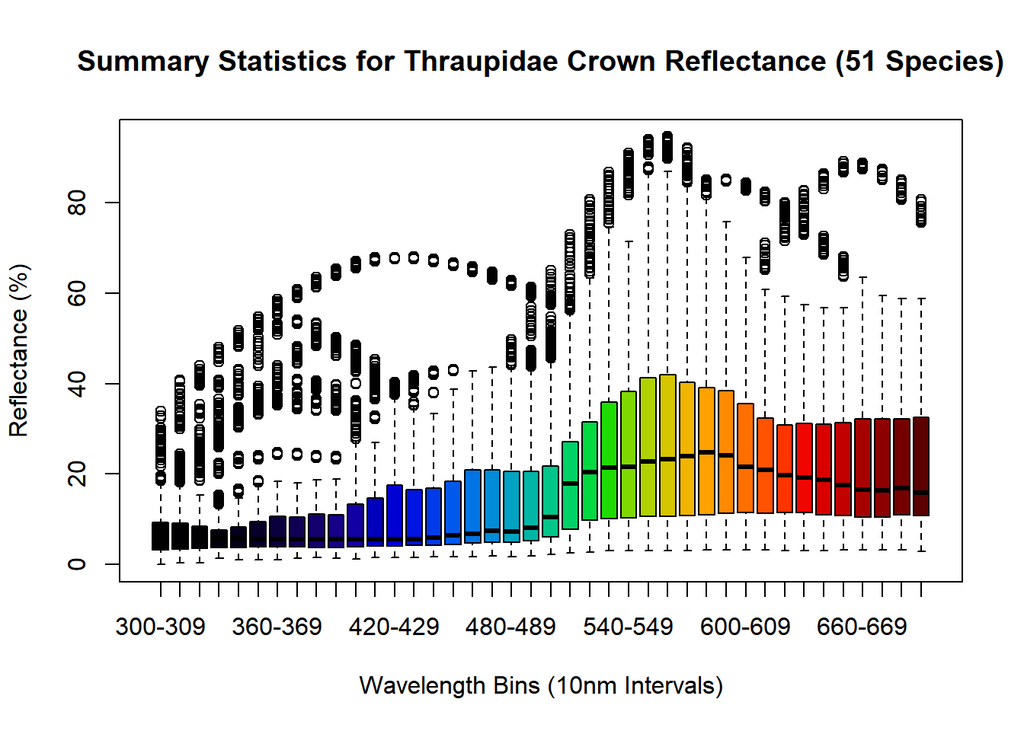

```r
# Sequence vector with the midpoints of our wavelength bins
sequence <- seq(305, 695, 10)

# Blank vectors to store RGB codes into
color_for_plots_V1 <- NULL
color_for_plots_V2 <- NULL
color_for_plots_V3 <- NULL
color_for_plots_V4 <- NULL

# for loop to generate different color options for the boxplots. Here we parameterize different Gaussian curves of spectra at the midpoint of each wavelength interval with varying widths and heights of our curves.
for (i in 1:length(sequence)){

  color_for_plots_V1[i] <- spec2rgb(simulate_spec(wl_peak = sequence[i]))

  color_for_plots_V2[i] <- spec2rgb(simulate_spec(wl_peak = sequence[i], width_gauss = 10))

  color_for_plots_V3[i] <- spec2rgb(simulate_spec(wl_peak = sequence[i], width_gauss = 10, ylim = c(0, wl_summary_stats[i,1])))

  color_for_plots_V4[i] <- spec2rgb(simulate_spec(wl_peak = sequence[i], ylim = c(0, wl_summary_stats[i,1])))
}


# Boxplots of the reflectance data for each wavelength bin with different color options

boxplot(data = wl_dataframe, Reflectance_Values~Wavelength_Bins, col = color_for_plots_V1, main = "Summary Statistics for Thraupidae Crown Reflectance (51 Species)", xlab = "Wavelength Bins (10nm Intervals)", ylab = "Reflectance (%)")
```

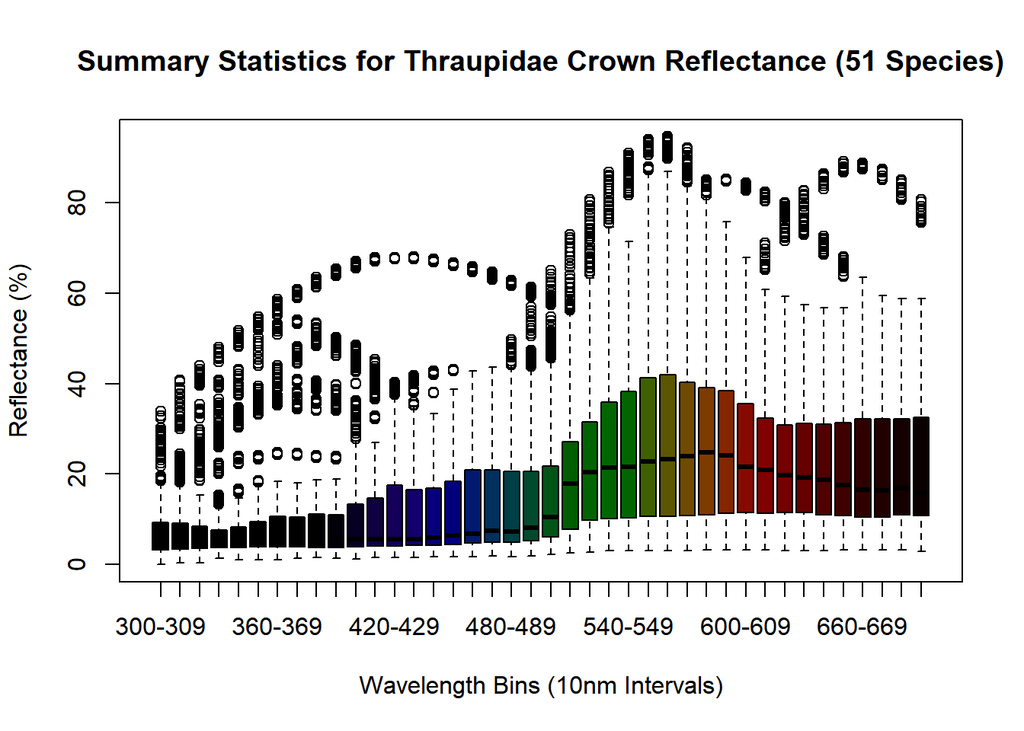

```r
boxplot(data = wl_dataframe, Reflectance_Values~Wavelength_Bins, col = color_for_plots_V2, main = "Summary Statistics for Thraupidae Crown Reflectance (51 Species)", xlab = "Wavelength Bins (10nm Intervals)", ylab = "Reflectance (%)")
```

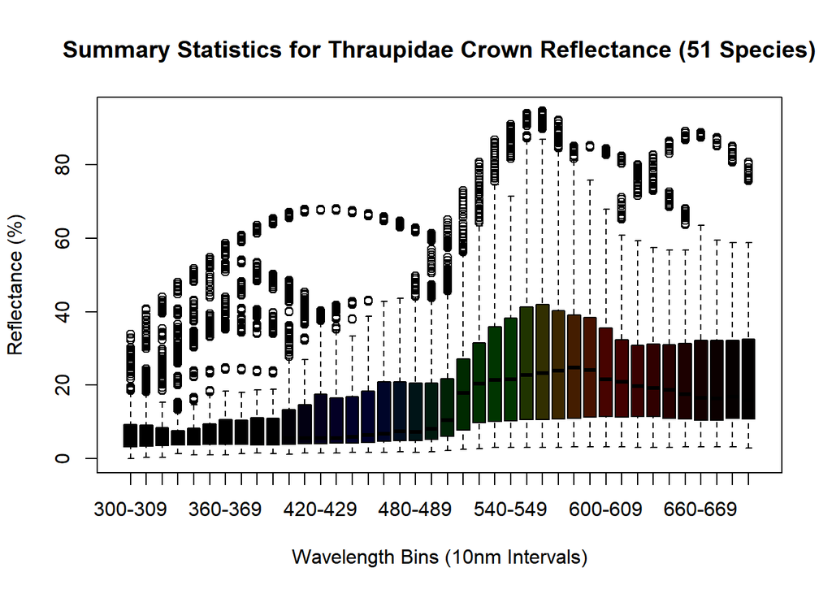

```r
boxplot(data = wl_dataframe, Reflectance_Values~Wavelength_Bins, col = color_for_plots_V3, main = "Summary Statistics for Thraupidae Crown Reflectance (51 Species)", xlab = "Wavelength Bins (10nm Intervals)", ylab = "Reflectance (%)")
```

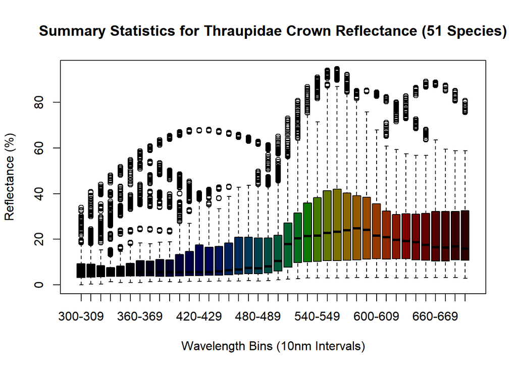

```r
boxplot(data = wl_dataframe, Reflectance_Values~Wavelength_Bins, col = color_for_plots_V4, main = "Summary Statistics for Thraupidae Crown Reflectance (51 Species)", xlab = "Wavelength Bins (10nm Intervals)", ylab = "Reflectance (%)")
```

### Step 10: Spline Coefficient Extraction for BEAST

```r
# Empty matrix for the spline coefficients
spline_coef_data <- NA

# for loop to extract spline coefficients for each species from our spline_results (list)
for (species_name in names(spline_results)){

  name_vector <- as.character(species_name)

  spline_coefficients <- spline_results[[name_vector]]

  spline_coefficients <- spline_coefficients$reflectance_coef

  spline_coef_data <- rbind(spline_coef_data, spline_coefficients)


}

# Removes NA row
spline_coef_data <- spline_coef_data[-1,]

# Turns our matrix into a data frame
spline_coef_data <- data.frame(spline_coef_data)

# Adds species labels to each row of spline coefficients
rownames(spline_coef_data) <- names(spline_results)

# Explicit species name vector to add to our data frame
species <- as.character(names(spline_results))

# Adds a species name vector to our data frame. This is needed for BEAST to know what spline coefficients are for each species
spline_coef_data <- cbind(species, spline_coef_data)

# Vector containing the names of the species column and each spline coefficient extracted
coefficient_names <- c("Species", "Intercept", "Coefficient.1","Coefficient.2","Coefficient.3","Coefficient.4","Coefficient.5","Coefficient.6","Coefficient.7","Coefficient.8","Coefficient.9","Coefficient.10","Coefficient.11","Coefficient.12","Coefficient.13","Coefficient.14","Coefficient.15","Coefficient.16","Coefficient.17","Coefficient.18","Coefficient.19","Coefficient.20","Coefficient.21","Coefficient.22","Coefficient.23","Coefficient.24","Coefficient.25","Coefficient.26","Coefficient.27","Coefficient.28","Coefficient.29","Coefficient.30","Coefficient.31","Coefficient.32","Coefficient.33","Coefficient.34","Coefficient.35","Coefficient.36","Coefficient.37","Coefficient.38")

# Applies our coefficient name vector to our data frame
colnames(spline_coef_data) <- coefficient_names

# Verifies our data is in a data frame
str(spline_coef_data)
```

```
## 'data.frame':    51 obs. of  40 variables:
##  $ Species       : chr  "TanCyo" "TanLab" "TanRue" "TanChi" ...
##  $ Intercept     : num  4.69 8.74 5 1.55 3.55 ...
##  $ Coefficient.1 : num  -1.95 3.72 0.82 1.35 1.24 2.11 0.4 -0.17 0.48 2.22 ...
##  $ Coefficient.2 : num  2.17 -5.3 -0.09 -0.19 0.14 0.78 1.14 1.54 -0.39 -1.14 ...
##  $ Coefficient.3 : num  0.58 1.19 -0.08 1.46 0.04 2.27 -1.12 1.37 -1.98 -2.47 ...
##  $ Coefficient.4 : num  2.96 -2.37 0.15 0.56 0.4 2.31 1.19 3.12 -0.77 -0.73 ...
##  $ Coefficient.5 : num  2.43 -3.35 0.26 0.57 0.06 3.22 0.19 1.65 -0.22 0.45 ...
##  $ Coefficient.6 : num  1.04 -3.7 0.46 0.57 0.67 3.33 1.09 2.08 1.23 -0.08 ...
##  $ Coefficient.7 : num  2.21 -4.4 1.22 0.69 -0.29 3.9 0.74 2.76 2.27 2.47 ...
##  $ Coefficient.8 : num  1.82 -4.37 2.11 1.05 -0.08 4.91 1.22 2.61 4.01 3.68 ...
##  $ Coefficient.9 : num  1.93 -3.82 2.34 1.26 0.18 5.57 1.4 3.16 5.47 5.14 ...
##  $ Coefficient.10: num  1.81 -3.39 2.73 0.99 0.1 6.93 0.89 3.62 7.28 7.63 ...
##  $ Coefficient.11: num  2.03 -3.2 2.91 0.73 0.54 ...
##  $ Coefficient.12: num  2 -2.93 3.06 0.39 0.76 ...
```

[output cut: 26 more lines]

```r
# Writes a text file of our data frame to use for BEAST
write_tsv(spline_coef_data, file = "spline_coefficients_BEAST.txt")
```

# Step 11: OUTLINING BEAST AND TRACER PROCESS

# Step 12: Analyzing diffusion rates of spline coefficients

```r
# Loads in the .txt file containing our diffusion rate data for our spline coefficients
coefficient_diffusion_rates <- read.delim("diffusion_rate_data.txt")

# Manually written vector to contain an ordered list of the spline coefficients
coefficient_diffusion_rates_names <- c("Intercept.diffusionRate", "Coefficient.1.diffusionRate","Coefficient.2.diffusionRate","Coefficient.3.diffusionRate","Coefficient.4.diffusionRate","Coefficient.5.diffusionRate","Coefficient.6.diffusionRate","Coefficient.7.diffusionRate","Coefficient.8.diffusionRate","Coefficient.9.diffusionRate","Coefficient.10.diffusionRate","Coefficient.11.diffusionRate","Coefficient.12.diffusionRate","Coefficient.13.diffusionRate","Coefficient.14.diffusionRate","Coefficient.15.diffusionRate","Coefficient.16.diffusionRate","Coefficient.17.diffusionRate","Coefficient.18.diffusionRate","Coefficient.19.diffusionRate","Coefficient.20.diffusionRate","Coefficient.21.diffusionRate","Coefficient.22.diffusionRate","Coefficient.23.diffusionRate","Coefficient.24.diffusionRate","Coefficient.25.diffusionRate","Coefficient.26.diffusionRate","Coefficient.27.diffusionRate","Coefficient.28.diffusionRate","Coefficient.29.diffusionRate","Coefficient.30.diffusionRate","Coefficient.31.diffusionRate","Coefficient.32.diffusionRate","Coefficient.33.diffusionRate","Coefficient.34.diffusionRate","Coefficient.35.diffusionRate","Coefficient.36.diffusionRate","Coefficient.37.diffusionRate","Coefficient.38.diffusionRate")

# Blank vector to store the order of the columns in relation to the order of our spline coefficient names vector
diffusion_rate_column_order <- NULL

# for loop to figure out the location of each column to to put it in sequential order (Intercept, 1, 2, ..., 38). This step is necessary as the columns are not in this sequential order when extracted from BEAST.
for (i in 1:length(coefficient_diffusion_rates_names)){
  diffusion_rate_column_order[i] <- which(coefficient_diffusion_rates_names[i] == colnames(coefficient_diffusion_rates))
    print(which(coefficient_diffusion_rates_names[i] == colnames(coefficient_diffusion_rates)))
}
```

```
## [1] 2
## [1] 39
## [1] 37
## [1] 35
## [1] 33
## [1] 31
## [1] 29
## [1] 27
## [1] 25
## [1] 4
## [1] 16
## [1] 14
## [1] 20
## [1] 18
## [1] 9
```

[output cut: 24 more lines]

```r
# Reorders the columns of our data frame to match the sequential order that we would like
coefficient_diffusion_rates <- coefficient_diffusion_rates[,c(1,diffusion_rate_column_order)]

# Verifies that we have the correct order that we are looking for
head(coefficient_diffusion_rates)
```

```
##   Summary.Statistic Intercept.diffusionRate Coefficient.1.diffusionRate
## 1              mean                  0.7889                      0.0847
## 2    stderr of mean               7.4599E-4                   7.9451E-5
## 3             stdev                  0.0693                   7.5383E-3
## 4          variance                4.798E-3                   5.6825E-5
## 5            median                  0.7838                      0.0839
## 6       value range        [0.5862, 1.1051]            [0.0649, 0.1245]
##   Coefficient.2.diffusionRate Coefficient.3.diffusionRate
## 1                       0.141                      0.1607
## 2                   1.5355E-4                   1.5071E-4
## 3                      0.0144                       0.014
## 4                   2.0831E-4                   1.9613E-4
## 5                      0.1399                      0.1594
## 6            [0.1006, 0.2095]            [0.1198, 0.2386]
##   Coefficient.4.diffusionRate Coefficient.5.diffusionRate
```

[output cut: 125 more lines]

```r
# Transposes the data frame to make the coefficients the rows
coefficient_diffusion_rates <- t(coefficient_diffusion_rates)

# When transposing the data frame, our data frame became a matrix, and here we convert it back into a data frame
coefficient_diffusion_rates <- data.frame(coefficient_diffusion_rates)

# Turns the column names with the values in the first row
colnames(coefficient_diffusion_rates) <- coefficient_diffusion_rates[1,]

# We remove the first row as they are now the column names for our data frame
coefficient_diffusion_rates <- coefficient_diffusion_rates[-1,]

# Verifies the structure of our object. We can see that all numerical values had been coerced into character vectors
str(coefficient_diffusion_rates)
```

```
## 'data.frame':    39 obs. of  11 variables:
##  $ mean                       : chr  "0.7889" "0.0847" "0.141" "0.1607" ...
##  $ stderr of mean             : chr  "7.4599E-4" "7.9451E-5" "1.5355E-4" "1.5071E-4" ...
##  $ stdev                      : chr  "0.0693" "7.5383E-3" "0.0144" "0.014" ...
##  $ variance                   : chr  "4.798E-3" "5.6825E-5" "2.0831E-4" "1.9613E-4" ...
##  $ median                     : chr  "0.7838" "0.0839" "0.1399" "0.1594" ...
##  $ value range                : chr  "[0.5862, 1.1051]" "[0.0649, 0.1245]" "[0.1006, 0.2095]" "[0.1198, 0.2386]" ...
##  $ geometric mean             : chr  "0.7859" "0.0843" "0.1403" "0.1601" ...
##  $ 95% HPD interval           : chr  "[0.6606, 0.9279]" "[0.0701, 0.0989]" "[0.1151, 0.171]" "[0.1355, 0.1895]" ...
##  $ auto-correlation time (ACT): chr  "1044.1002" "1000" "1018.8544" "1042.5656" ...
##  $ effective sample size (ESS): chr  "8620.8" "9001" "8834.4" "8633.5" ...
##  $ number of samples          : chr  "9001" "9001" "9001" "9001" ...
```

```r
# for loop to convert all columns into numerical values rather than character values (with the exception of the 95% HPD interval and value range columns as there are not singular values and do not work the as.numeric function)
for (i in c(1:5,7,9:11)){
coefficient_diffusion_rates[,i] <- as.numeric(coefficient_diffusion_rates[,i])
}

# Verifies that the columns that we converted are now numeric in nature
str(coefficient_diffusion_rates)
```

```
## 'data.frame':    39 obs. of  11 variables:
##  $ mean                       : num  0.7889 0.0847 0.141 0.1607 0.2078 ...
##  $ stderr of mean             : num  7.46e-04 7.95e-05 1.54e-04 1.51e-04 1.98e-04 ...
##  $ stdev                      : num  0.0693 0.00754 0.0144 0.014 0.0182 ...
##  $ variance                   : num  4.80e-03 5.68e-05 2.08e-04 1.96e-04 3.32e-04 ...
##  $ median                     : num  0.7838 0.0839 0.1399 0.1594 0.2063 ...
##  $ value range                : chr  "[0.5862, 1.1051]" "[0.0649, 0.1245]" "[0.1006, 0.2095]" "[0.1198, 0.2386]" ...
##  $ geometric mean             : num  0.7859 0.0843 0.1403 0.1601 0.207 ...
##  $ 95% HPD interval           : chr  "[0.6606, 0.9279]" "[0.0701, 0.0989]" "[0.1151, 0.171]" "[0.1355, 0.1895]" ...
##  $ auto-correlation time (ACT): num  1044 1000 1019 1043 1069 ...
##  $ effective sample size (ESS): num  8621 9001 8834 8634 8421 ...
##  $ number of samples          : num  9001 9001 9001 9001 9001 ...
```

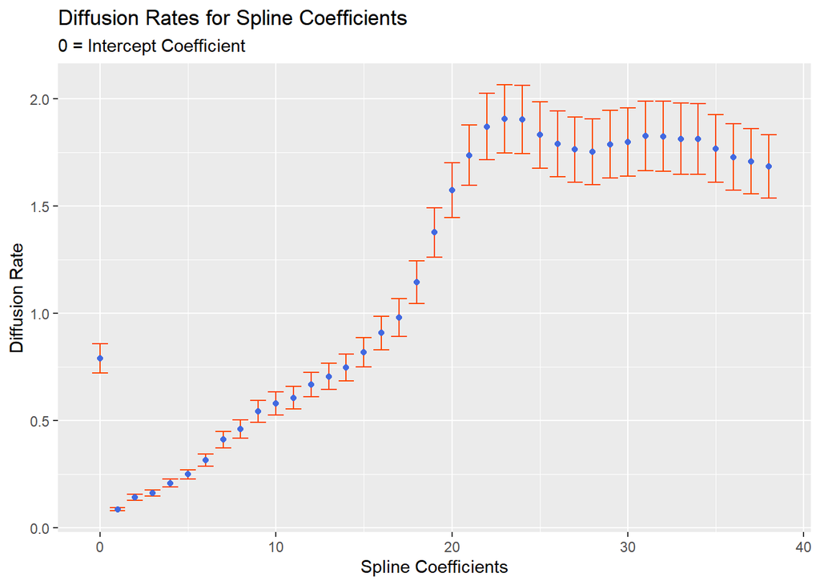

```r
# Scatterplot showing the mean diffusion rate values for our spline coefficients, showing error bars equivalent to +/- 1 standard deviation
(ggplot(coefficient_diffusion_rates, aes(x = 0:38, y = mean))
+ geom_errorbar(aes(ymax = mean+stdev, ymin = mean-stdev), color = "orangered")
+ geom_point(color = "royalblue")
+ ggtitle("Diffusion Rates for Spline Coefficients", subtitle = "0 = Intercept Coefficient")
+ xlab("Spline Coefficients")
+ ylab("Diffusion Rate")
)
```

# Step 13: Reconstucting splines (methods)

One of the main points of reconstructing splines is that we need to do it without the predictive power of a generalized least squares model, which is how we did it in Step 5. This is due to the fact that when we allow our coefficients to diffuse in BEAST for an ancestral state reconstruction (ASR), the only things that we have to reconstruct our diffused splines will just be diffused coefficients and the basis that we are working with (300-700 nm). Below, I will use a case study, using TanCyo (Tangara cyanotis) to show how we can construct splines for a species without the need for a least squares model.

#### Spline Reconstruction from gls function

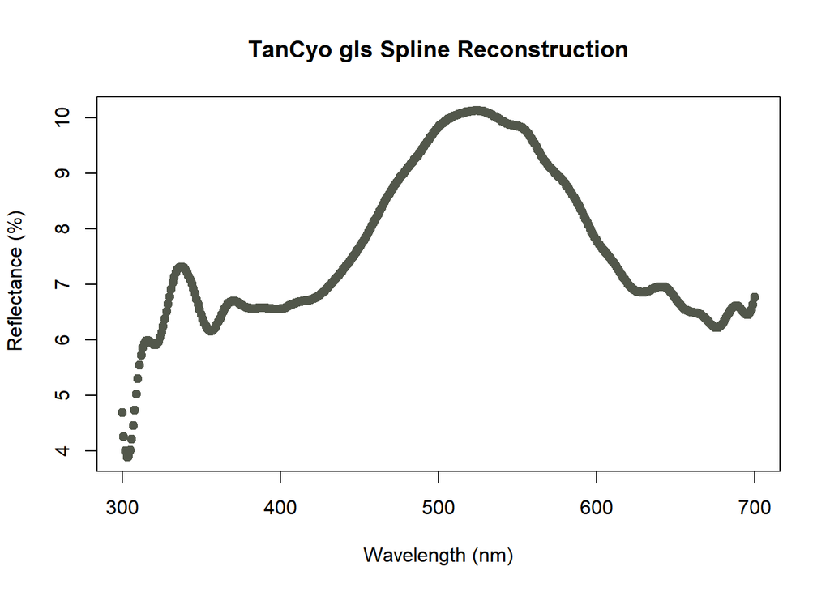

```r
# Extracting all of the data from our fit_splines function into a new object (named after our focal species)
TanCyo <- spline_results[["TanCyo"]]

# Here we plot a scatterplot using the predicted points from our gls model for this species
plot(x = 300:700, y = predict(TanCyo$reflectance_spline_fit), col = TanCyo$reflectance_rgb, pch = 19, xlab = "Wavelength (nm)", ylab = " Reflectance (%)", main = "TanCyo gls Spline Reconstruction")
```

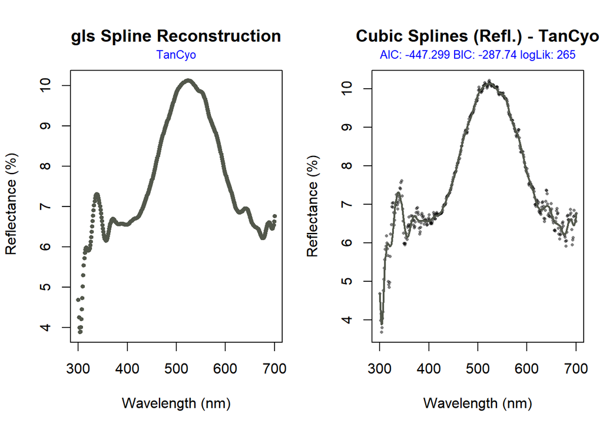

```r
# Side-by-side plot comparison of our gls reconstructed plot and the plot from Step 5 (using the actual reflectance data)

par(mfrow=c(1,2), mar = c(5.1,4.1,4.1,1.1))

plot(x = 300:700, y = predict(TanCyo$reflectance_spline_fit), col = TanCyo$reflectance_rgb, pch = 19, xlab = "Wavelength (nm)", ylab = " Reflectance (%)", main = "gls Spline Reconstruction", cex = 0.6)
mtext("TanCyo", col = "blue", side = 3, line = 0.5, cex = 0.8)

plot(tanData_filtered$wl, tanData_filtered$TanCyo, type = "p", pch = 16, cex = 0.5,  # Adjusted size of points
     col = adjustcolor("black", alpha.f = 0.5),  # Adjusted transparency of points
     main = paste("Cubic Splines (Refl.) -", "TanCyo"),
     xlab = "Wavelength (nm)", ylab = "Reflectance (%)")
lines(tanData_filtered$wl, predict(spline_results[["TanCyo"]]$reflectance_spline_fit), col = rgb_colors[["TanCyo"]], lwd = 2)
mtext(paste("AIC:", round(spline_results[["TanCyo"]]$reflectance_AIC, 3), "BIC:", round(spline_results[["TanCyo"]]$reflectance_BIC, 2), "logLik:", round(spline_results[["TanCyo"]]$reflectance_logLik)),
      side = 3, line = 0.5, cex = 0.8, col = "blue")
```

```r
par(mfrow=c(1,1), mar = c(5.1,4.1,4.1,2.1))
```

#### Spline Reconstruction with only spline coefficients and a basis

I could not find an intuitive way to do this through just base R, but by using the package splines2, I am able to reconstruct the splines with just this information available.

```r
# Creating a basis matrix using the function bSpline from the splines2 package. We use the same wavelength range and maintain the same degrees of freedom (35 knots)
bspline_matrix_bSpline <- bSpline(tanData_filtered$wl, df = 38)

# Verifying that the bSpline and bs functions produce identical basis matrices (output should be TRUE)
identical(data.frame(bs(tanData_filtered$wl, df = 38)), data.frame(bSpline(tanData_filtered$wl, df = 38)))
```

```
## [1] TRUE
```

```r
# Extract the coefficients available to us from our gls model fit into its own vector
TanCyo_spline_coefficients <- TanCyo$reflectance_coef

# Must make coefficients from 2:39 as bSpline function does not create an intercept coefficient in its output, and therefore cannot use it in reconstructions
coef_spline_reconstruction <- cbind(300:700, predict(bspline_matrix_bSpline, coef = as.numeric(c(TanCyo_spline_coefficients[2:39]))))

# Adds names to the columns of the matrix
colnames(coef_spline_reconstruction) <- c("wl", "reflectance")

# Turns the matrix into a data frame
coef_spline_reconstruction <- data.frame(coef_spline_reconstruction)

# Code to show why we need to use the splines2 package
# Basis matrix produced by the function bs
bspline_matrix_bs <- bs(tanData_filtered$wl, df = 38)

# Object that would be created using the bs produced matrix. The output is another matrix
str(predict(bspline_matrix_bs, coef = as.numeric(c(TanCyo_spline_coefficients[2:39]))))
```

```
##  'bs' num [1:401, 1:38] 0 0.235 0.404 0.516 0.578 ...
##  - attr(*, "dimnames")=List of 2
##   ..$ : NULL
##   ..$ : chr [1:38] "1" "2" "3" "4" ...
##  - attr(*, "degree")= int 3
##  - attr(*, "knots")= num [1:35] 311 322 333 344 356 ...
##  - attr(*, "Boundary.knots")= int [1:2] 300 700
##  - attr(*, "intercept")= logi FALSE
```

```r
# Object that would be created using the bSpline produced matrix. The output is a one column matrix (or a vector)
str(predict(bspline_matrix_bSpline, coef = as.numeric(c(TanCyo_spline_coefficients[2:39]))))
```

```
##  num [1:401] 0 -0.433 -0.694 -0.807 -0.794 ...
```

```
## wavelengths found in column 1
```

```
## The spectral data contain 7 negative value(s),
##  which may produce unexpected results if used in models.
## Consider using procspec() to correct them.
```

```
## processing options applied:
## Negative value correction: converted negative values to zero
```

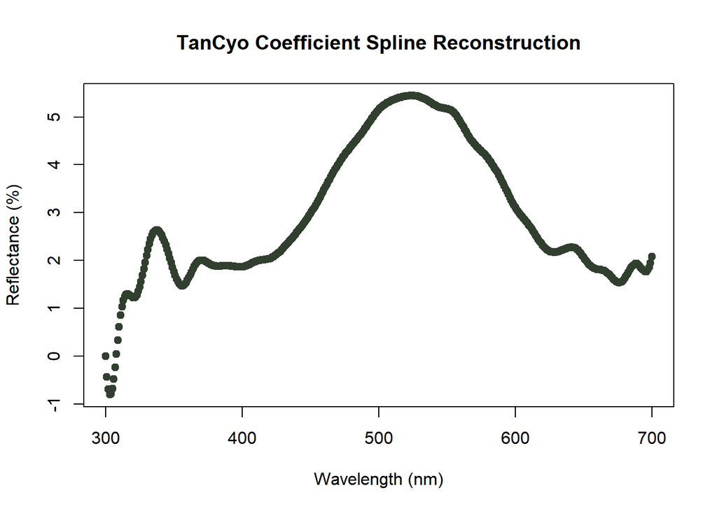

```r
# Plotting the spline reconstruction using our matrix/coef method
plot(x = 300:700, y = coef_spline_reconstruction$reflectance, pch = 19, main = "TanCyo Coefficient Spline Reconstruction", xlab = "Wavelength (nm)", ylab = "Reflectance (%)", col = spec2rgb(procspec(as.rspec(coef_spline_reconstruction), fixneg = "zero")))
```

```r
# Side-by-side plots of the gls reconstruction and matrix/coef reconstruction
par(mfrow=c(1,2), mar = c(5.1,4.1,4.1,1.1))

plot(x = 300:700, y = predict(TanCyo$reflectance_spline_fit), col = TanCyo$reflectance_rgb, pch = 19, xlab = "Wavelength (nm)", ylab = " Reflectance (%)", main = "gls Spline Reconstruction", cex = 1)
mtext("TanCyo", col = "blue", side = 3, line = 0.5, cex = 0.8)


plot(x = 300:700, y = coef_spline_reconstruction$reflectance, pch = 19, main = "Coefficient Spline Reconst.", xlab = "Wavelength (nm)", ylab = "Reflectance (%)", col = spec2rgb(procspec(as.rspec(coef_spline_reconstruction), fixneg = "zero")))
```

```
## wavelengths found in column 1
```

```
## The spectral data contain 7 negative value(s),
##  which may produce unexpected results if used in models.
## Consider using procspec() to correct them.
```

```
## processing options applied:
## Negative value correction: converted negative values to zero
```

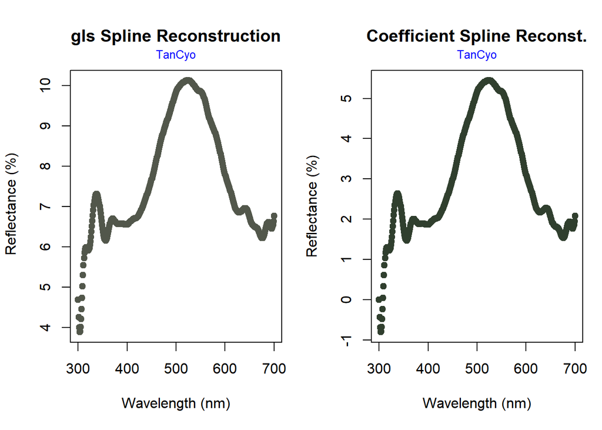

```r
mtext("TanCyo", col = "blue", side = 3, line = 0.5, cex = 0.8)
```

```r
par(mfrow=c(1,1), mar = c(5.1,4.1,4.1,2.1))
```

From the plots above, we can see two key differences from our initial plot. The first is that the color between the plots. The gls plot has an RGB color of #52574BFF, while the coefficient method has a color of #303F2EFF. The next major difference (and directly impacts why there is a color change), is that the reflectance scales are completely different from another, with all values on the left plot being greater than 0, while the data points on the right plot do not follow that trend. So if using a basis and spline coefficients to rebuild a curve, will we lose all of the biological information, where we only retain the shape of the curve? No. Earlier in our reconstruction, we mentioned that we had to omit the intercept coefficient due to `predict(bspline_matrix_bSpline, coef = as.numeric(c(TanCyo_spline_coefficients[2:39])))` not being able to use it. But the intercept coefficient is important in dictating where to place the spline along the y-axis, thus all we have to do to our data is to add the spline coefficient value to all of our data points.

```r
# Prints TanCyo intercept coefficient
TanCyo$reflectance_coef[1]
```

```
## (Intercept)
##        4.69
```

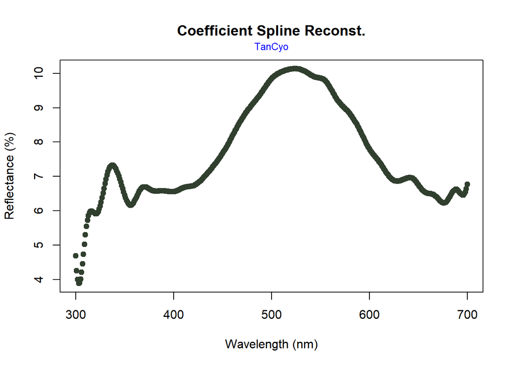

```r
# Plots the reconstructed splines from the matrix/coef method but adds the intercept values to the reconstructed reflectance values
plot(x = 300:700, y = coef_spline_reconstruction$reflectance + TanCyo$reflectance_coef[1], pch = 19, main = "Coefficient Spline Reconst.", xlab = "Wavelength (nm)", ylab = "Reflectance (%)", col = spec2rgb(procspec(as.rspec(coef_spline_reconstruction), fixneg = "zero")))
mtext("TanCyo", col = "blue", side = 3, line = 0.5, cex = 0.8)
```

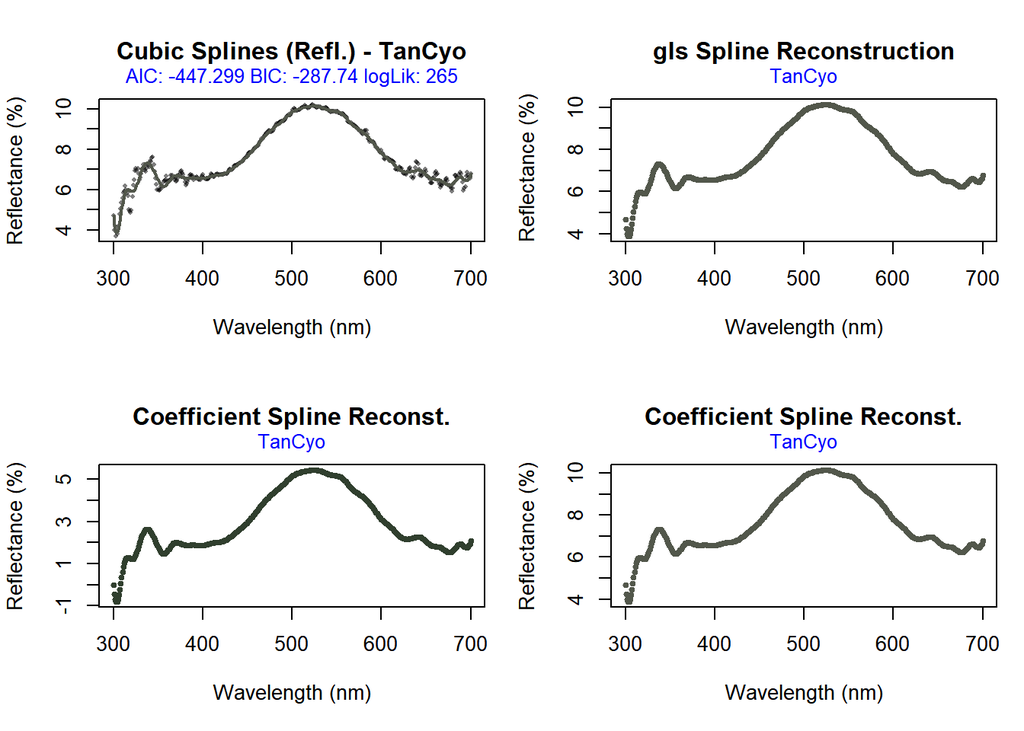

```r
# Copies our coef_spline_reconstruction data frame
coef_spline_reconstruction_plusintercept <- coef_spline_reconstruction

# Adds the intercept coefficient value to all of the reflectance values
coef_spline_reconstruction_plusintercept$reflectance <- coef_spline_reconstruction_plusintercept$reflectance + TanCyo$reflectance_coef[1]

# Side-by-side plots of the initial data, gls reconstruction, matrix/coef reconstruction, modified matrix/coef reconstruction
par(mfrow=c(2,2), mar = c(5.1,4.1,4.1,1.1))

plot(tanData_filtered$wl, tanData_filtered$TanCyo, type = "p", pch = 16, cex = 0.5,  # Adjusted size of points
     col = adjustcolor("black", alpha.f = 0.5),  # Adjusted transparency of points
     main = paste("Cubic Splines (Refl.) -", "TanCyo"),
     xlab = "Wavelength (nm)", ylab = "Reflectance (%)")
lines(tanData_filtered$wl, predict(spline_results[["TanCyo"]]$reflectance_spline_fit), col = rgb_colors[["TanCyo"]], lwd = 2)
mtext(paste("AIC:", round(spline_results[["TanCyo"]]$reflectance_AIC, 3), "BIC:", round(spline_results[["TanCyo"]]$reflectance_BIC, 2), "logLik:", round(spline_results[["TanCyo"]]$reflectance_logLik)),
      side = 3, line = 0.5, cex = 0.8, col = "blue")

plot(x = 300:700, y = predict(TanCyo$reflectance_spline_fit), col = TanCyo$reflectance_rgb, pch = 19, xlab = "Wavelength (nm)", ylab = " Reflectance (%)", main = "gls Spline Reconstruction", cex = 0.6)
mtext("TanCyo", col = "blue", side = 3, line = 0.5, cex = 0.8)


plot(x = 300:700, y = coef_spline_reconstruction$reflectance, pch = 19, main = "Coefficient Spline Reconst.", xlab = "Wavelength (nm)", ylab = "Reflectance (%)", cex = 0.6, col = spec2rgb(procspec(as.rspec(coef_spline_reconstruction), fixneg = "zero")))
mtext("TanCyo", col = "blue", side = 3, line = 0.5, cex = 0.8)

plot(x = 300:700, y = coef_spline_reconstruction_plusintercept$reflectance, pch = 19, main = "Coefficient Spline Reconst.", xlab = "Wavelength (nm)", ylab = "Reflectance (%)", cex = 0.6, col = spec2rgb(procspec(as.rspec(coef_spline_reconstruction_plusintercept), fixneg = "zero")))
mtext("TanCyo", col = "blue", side = 3, line = 0.5, cex = 0.8)
```

```r
par(mfrow=c(1,1), mar = c(5.1,4.1,4.1,2.1))


# Verification that our final spline reconstruction produces an identical color to the initial reflectance data and the gls reconstruction method

# Plot 1
rgb_colors[["TanCyo"]]
```

```
## [1] "#52574BFF"
```

```r
# Plot 2
TanCyo$reflectance_rgb
```

```
## reflectance
## "#52574BFF"
```

```r
# Plot 3
spec2rgb(procspec(as.rspec(coef_spline_reconstruction), fixneg = "zero"))
```

```
## reflectance
## "#303F2EFF"
```

```r
# Plot 4
spec2rgb(procspec(as.rspec(coef_spline_reconstruction_plusintercept), fixneg = "zero"))
```

```
## reflectance
## "#52574BFF"
```

Thus, we have shown we have accurately recreated the spline from our gls model and can produce identical colors to that of the original data just from the spline coefficients for a species and by using a basis for the trait data.